# HW#4:Stringr & Air Quality Data

Vicky Espinoza

Due March 07, 2018

```r
require(tidyverse)
require(dplyr)
require(data.table)
require(stringr)
require(stringi)
```

## R Book: Chapter 11 - Strings with stringr Exercises

1. Complete the tutorial steps for Strings from Chapter 14 in your R for Data Science text book http://r4ds.had.co.nz/strings.html. Answer all of the exercise questions in Chapter 14. Turn in your responses as R notebook file (.html) as a commit to your GitHub page. Turn in all of your functions as separate function (.R) files with intelligible titles as a commit to your GitHub page.

## String Basics

1. What is the difference between paste() and paste0()? What stringr function are they equivalent to? How do the functions differ in handling NA?

paste () converts arguments to character strings, and concatenates them with separation specified by sep. By default it separates strings by spaces. It coerces missing value characters to NA.

paste0() is more efficient than paste() at concantenating strings without spaces. NAs are taken as characters in the string.

2. Difference between sep and collapse arguments to str_c().

sep is the element that separates every term in a string, whereas, collapse will return concatenated pairs as part of a single character vector with tuples separated by the string passed by collapse.

3.str_length() and str_sub() to extract the middle character from a string. what will you do if the string has an even number of characters?

```r
library(tidyverse)
library(stringr)
x <- c("abc", "abcd")
y <- str_length(x)
z <- ceiling(y / 2)
str_sub(x, z, z)
```

```
## [1] "b" "b"
```

When there are even number then the choice is arbituary and the ceiling or floor function is selected by the user in order to select the middle value.

4. What does `str_wrap()` do? When might you want to use it?

This function wraps the text so that it fits within a certain width. Might want to use it when typing long strings of text.

5.What does `str_trim()` do? What’s the opposite of `str_trim()`?

`str_trim()` trims the white space of a string and can specify the side that we want white space trimmed from, either left or right side as demonstrated below:

```r
str_trim(" Data! ")
```

```
## [1] "Data!"
```

```r
str_trim(" Data! ", side = "left")
```

```
## [1] "Data! "
```

```r
str_trim(" Data! ", side = "right")
```

```
## [1] " Data!"
```

The opposite of `str_trim()` is str_pad which adds characters to either side of the string.

```r
str_pad("Data!",7, side = "both")
```

```
## [1] " Data! "
```

```r
str_pad("Data!",6, side = "right")
```

```
## [1] "Data! "
```

```r
str_pad("Data!",10, side = "left")
```

```
## [1] "     Data!"
```

6. Write a function that turns a vector c(“a”, “b”, “c”) into the string a, b, and c. Think carefully about what it should do if given a vector of length 0,1, or 2.

```r
commasep <- function(x, sep = ", ", last = ", and ") {
  if (length(x) > 1) {
    str_c(str_c(x[-length(x)], collapse = sep),
                x[length(x)],
                sep = last)
  } else {
    x
  }
}
commasep("a")
```

```
## [1] "a"
```

```r
commasep("data")
```

```
## [1] "data"
```

```r
commasep(c("data", "stats", "analysis"))
```

```
## [1] "data, stats, and analysis"
```

## Matching Patterns with Regular Expressions

1. Explain why each of these strings don’t match a : “",”\“,”\".

`"\"`: escapes the next character in a R string `"\\"`: this creates a regular expression which will escape the next character in the string `"\\\"`: first two backlashes of this resolves the backlash of the regular expression and the third backlash escapes the next character in the string. it’s the escape of a character in a regular expression

2. How would you match the sequence `"'\` ?

```r
a <- "\"'\\"
writeLines(a)
```

```
## "'\
```

```r
str_view(a,"\\\"'\\\\")
```

[interactive chart not shown]

3. What patterns will the regular expression ...... match? How would you represent it as a string?

This expression will match strings with patterns that have a dot followed by a character (repeated 3x).

To match it:

```r
a <- ".a.b.c"
writeLines(a)
```

```
## .a.b.c
```

```r
str_view(a, "\\..\\..\\..")
```

[interactive chart not shown]

How would you match the literal string `"$^$"`?

```r
string1 <- "$^$"
writeLines(string1)
```

```
## $^$
```

```r
str_view(string1, "\\$\\^\\$")
```

[interactive chart not shown]

Given the corpus of common words in stringr::words, create regular expressions that find all words that:

a. Start with “y”.

```r
data(words)
str_view(words, "^y", match = TRUE)
```

[interactive chart not shown]

b. End with “X”.

```r
str_view(words, "x$", match = TRUE)
```

[interactive chart not shown]

c.Are exactly three letters long.

```r
str_view(words, "^\\w{3}$", match = TRUE)
```

[interactive chart not shown]

Note: This can also be done using str_length.

d. Have seven letters or more.

```r
str_view(words, "^\\w{7,}$", match = TRUE)
```

[interactive chart not shown]

## Character Classes and Alternatives

1. Create regular expressions to find all words that:

a.Start with a vowel

```r
str_view(words, "^[aeiouy]", match=T)
```

[interactive chart not shown]

b. Contain only consonants (matching non-vowels)

```r
str_view(words, "^[^aeouiy]$", match = T)
```

[interactive chart not shown]

c. End with `ed`, but not with `eed`

```r
str_view(words, "[^e]ed$", match = T)
```

[interactive chart not shown]

d. End with `ing` or `ize`

```r
str_view(words, "ing$|ize$")
```

[interactive chart not shown]

2. Empirically verify the rule “i before e except after c.”

```r
str_view(words, "([^c]|)ei", match = T)
```

[interactive chart not shown]

```r
#the answer is not always the case
```

3.Is “q” always followed by a “u”?

```r
str_view(words, "q[^u]", match = T)
```

[interactive chart not shown]

```r
#Yes!
```

4. Write a regular expression that matches a word if it;s probably written in British English, not American English.

```r
data(words)
str_view(words, "ize", match = T)
```

[interactive chart not shown]

```r
american_british <- tibble::tribble(
  ~American.English, ~British.English,
            "color",         "colour",
         "behavior",      "behaviour",
          "theater",        "theatre",
         "behavior",      "behaviour",
            "meter",          "metre",
         "organize",       "organise",
         "traveled",      "travelled"
  )
str_view(american_british[[1]], "our$|re$|se$|lled")
```

[interactive chart not shown]

```r
str_view(american_british[[2]], "our$|re$|se$|lled")
```

[interactive chart not shown]

Create a regular expression that will match telephone numbers as commonly written in your country.

```r
phone_numbers <- tibble::tribble(
                      ~phone_numbers,
                    "(818) 257-1201",
                    "(818)-257-1201",
                      "818-257-1201",
                          "257-1201",
                          "257 1201",
                          "2571201")
str_view(phone_numbers[[1]],"^\\(?\\d{3}\\)?[\\s|-](\\d{3}[\\s|-]{1}\\d{4}$|\\d{4}$)")
```

[interactive chart not shown]

## Repetition

1. Describe the equivalents of ?, +, * in {m,n} form. `?: {0,1}` `+ : {1,}` `* : {0,}`

2.Describe in words what these regular expressions match (read carefully to see if I’m using a regular expression or a string that defines a regular expression):

a.^.*$ Matches any character from beginning of the string to the end of string. Matches any input.

b.`"\\{.+\\}"` Matches a backlash, open curly bracket, any character, backlash and closed curly bracket.

c.`\d{4}-\d{2}-\d{2}` Matches 4 digits, a dash, 2 digits, a dash, and 2 digits

d.`"\\\\{4}"` Matches `\\\\`

3. Create regular expressions to find all the words that:

a. Start with three consonants.

```r
str_view(words, "^[^aeouiy]{3}", match = T)
```

[interactive chart not shown]

b.Have 3+ vowels in a row

```r
str_view(words, "[aeouiy]{3,}", match = T)
```

[interactive chart not shown]

c.Have 2+ vowel-constant pairs in a row

```r
str_view(words, "([aeouiy][^aeouiy]){2,}", match = T)
```

[interactive chart not shown]

4. Solve the beginner regexp crosswords at https://regexcrossword.com/challenges/beginner

1. Beatles TOP:H,E BOTTOM:L,P HELP

2. Naughty TOP:B,O BOTTOM:B,E BOBE

3. Ghost TOP:O,O BOTTOM:O,O OOOO

4.Symbolism TOP:`*,*` BOTTOM:`/,/` `**//`

5. Airstrip One TOP:1,9 BOTTOM:8,4 1894

## Grouping and Backreferences

1. Describe, in words, what these expressions will match: 1. (.) Results in 3 characters 3 times in a row

2. `"(.)(.)\\2\\1"` A pair of two characters followed by the same pair of characters in reverse order

3`.(..)\1` Two characters repeated

4. `"(.).\\1.\\1"` A character (original) followed by any character, the original character, any other character, the original character

5. `"(.)(.)(.).*\\3\\2\\1"` This matches 3 characters followed by 0+ characters (any kind) followed by the same three characters in reverse order.

2.Construct regular expressions to match words that:

Construct regular expressions to match words that:

a.Start and end with the same character. `^(.).*\1$`

```r
str_view(words, "^(.).*\\1$")
```

[interactive chart not shown]

b.Contain a repeated pair of letters `"(..).*\\1"`

```r
str_view(words, "(..).*\\1")
```

[interactive chart not shown]

c.Contain one letter repeated in at least three places

```r
str_view(words,"([a-z]).*\\1.*\\1")
```

[interactive chart not shown]

## Tools: Detect Matches

1.For each of the following challenges, try solving it by using both a single regular expression, and a combination of multiple str_detect() calls:

a.Find all words that start or end with x.

```r
start_with_x <- str_detect(words, "^x")
end_with_x <- str_detect(words, "x$")
words[start_with_x | end_with_x]
```

```
## [1] "box" "sex" "six" "tax"
```

b.Find all words that start with a vowel and end with a consonant.

```r
str_subset(words, "^[aeiou].*[^aeiou]$") %>% head()
```

```
## [1] "about"   "accept"  "account" "across"  "act"     "actual"
```

```r
start_with_vowel <- str_detect(words, "^[aeiou]")
end_with_consonant <- str_detect(words, "[^aeiou]$")
words[start_with_vowel & end_with_consonant] %>% head()
```

```
## [1] "about"   "accept"  "account" "across"  "act"     "actual"
```

c. Are there any words that contain at least one of each different vowel? No there are no words that contain at least one of each different vowel.

```r
library(stringr)
words[str_detect(words, "a") &
        str_detect(words, "e") &
        str_detect(words, "i") &
        str_detect(words, "o") &
        str_detect(words, "u")]
```

```
## character(0)
```

d.What word has the highest number of vowels? What word has the highest proportion of vowels?(Hint what is the denominator)

```r
vowels<- str_count(words, "[aeiou]") / str_length(words)
words[which(vowels == max(vowels))]
```

```
## [1] "a"
```

## Tools: Extract Matches

1. In the previous example, you might have noticed that the regular expression matched flickered, which is not a color. Modify the regex to fix the problem.

This was the previous expression:

```r
colors <- c("red", "orange", "yellow", "green", "blue", "purple")
color_match <- str_c(colors, collapse = "|")
sentence<- sentences[str_count(sentences,color_match)>1]
sentence
```

```
## [1] "It is hard to erase blue or red ink."
## [2] "The green light in the brown box flickered."
## [3] "The sky in the west is tinged with orange red."
```

The word flickered because it has the color red embedded in the word.

```r
colors <- c("red", "orange", "yellow", "green", "blue", "purple")
color_match<- str_c("\\b(", str_c(colors, collapse = "|"), ")\\b")
sent<- sentences[str_count(sentences,color_match)>1]
sent
```

```
## [1] "It is hard to erase blue or red ink."
## [2] "The sky in the west is tinged with orange red."
```

2.From the Harvard sentence data, extract: a.The first word from each sentence

```r
str_extract(sentences, "[a-zA-X]+") %>% head()
```

```
## [1] "The"   "Glue"  "It"    "These" "Rice"  "The"
```

b. All words ending in -ing

```r
pattern <- "\\b[A-Za-z]+ing\\b"
ing_sentence <- str_detect(sentences, pattern)
unique(unlist(str_extract_all(sentences[ing_sentence], pattern))) %>%
  head()
```

```
## [1] "spring"  "evening" "morning" "winding" "living"  "king"
```

c. All plurals

```r
unique(unlist(str_extract_all(sentences, "\\b[A-Za-z]{3,}s\\b"))) %>%
  head()
```

```
## [1] "planks" "days"   "bowls"  "lemons" "makes"  "hogs"
```

## Tools: Grouped Matches

1.Find all words that come after a “number” line “one” “two”, “three”, etc. Pull out both the number and the word.

```r
num<- "(one|two|three|four|five|six|seven|eight|nine|ten) +(\\S+)"
sentences[str_detect(sentences, num)] %>%
  str_extract(num)
```

```
##  [1] "ten served"    "one over"      "seven books"   "two met"
##  [5] "two factors"   "one and"       "three lists"   "seven is"
##  [9] "two when"      "one floor."    "ten inches."   "one with"
## [13] "one war"       "one button"    "six minutes."  "ten years"
## [17] "one in"        "ten chased"    "one like"      "two shares"
## [21] "two distinct"  "one costs"     "ten two"       "five robins."
## [25] "four kinds"    "one rang"      "ten him."      "three story"
## [29] "ten by"        "one wall."     "three inches"  "ten your"
## [33] "six comes"     "one before"    "three batches" "two leaves."
```

2.Find all contractions. Separate out the pieces before and after the apostrophe.

```r
contraction <- "([A-Za-z]+)'([A-Za-z]+)"
sentences %>%
  `[`(str_detect(sentences, contraction)) %>%
  str_extract(contraction)
```

```
##  [1] "It's"       "man's"      "don't"      "store's"    "workmen's"
##  [6] "Let's"      "sun's"      "child's"    "king's"     "It's"
## [11] "don't"      "queen's"    "don't"      "pirate's"   "neighbor's"
```

## Tools: Replacing Matches

1. Replace all forward slashes in a string with backslashes

```r
backslash <- str_replace_all("Desktop/vespinoza/Desktop/ENVE207", "\\/", "\\\\")
writeLines(backslash)
```

```
## Desktop\vespinoza\Desktop\ENVE207
```

2. Implement a simple version of str_to_lower() using replace_all()

```r
word<- c("HELLO", "DR", "ERIN", "HESTIR", "!")
lowercase <-str_replace_all(word, c("A"="a", "B"="b", "C"="c", "D"="d", "E"="e", "F"="f", "G"="g", "H"="h", "I"="i", "J"="j", "K"="k", "L"="l", "M"="m", "N"="n", "O"="o", "P"="p", "Q"="q", "R"="r", "S"="s", "T"="t", "U"="u", "V"="v", "W"="w", "X"="x", "Y"="y", "Z"="z"))
lowercase
```

```
## [1] "hello"  "dr"     "erin"   "hestir" "!"
```

3. Switch the first and last letters in words. Whcih of those strings are still words?

```r
switch <- str_replace_all(words, "^([A-Za-z])(.*)([a-z])$", "\\3\\2\\1")
still_words <-intersect(switch,words)
still_words
```

```
##  [1] "a"          "america"    "area"       "dad"        "dead"
##  [6] "lead"       "read"       "depend"     "god"        "educate"
## [11] "else"       "encourage"  "engine"     "europe"     "evidence"
## [16] "example"    "excuse"     "exercise"   "expense"    "experience"
## [21] "eye"        "dog"        "health"     "high"       "knock"
## [26] "deal"       "level"      "local"      "nation"     "on"
## [31] "non"        "no"         "rather"     "dear"       "refer"
## [36] "remember"   "serious"    "stairs"     "test"       "tonight"
## [41] "transport"  "treat"      "trust"      "window"     "yesterday"
```

45 words still remain words after swapping the first and last letters of words.

## Tools: Splitting

1.Split up a string like “apples, pears, and bananas” into individual components.

```r
x <- c("apples, pears, and bananas")
str_split(x, ", +(and +)?")[[1]]
```

```
## [1] "apples"  "pears"   "bananas"
```

2.Why is it better to split up by boundary(“word”) than " “? Splitting on boundary(”word“) splits on both white space and punctuation.

3.What does splitting with an empty string (“”) do? Experiment, and then read the documentation.

```r
str_split("Vi. ck|y", "")[[1]]
```

```
## [1] "V" "i" "." " " "c" "k" "|" "y"
```

It splits the string into individual characters.

## Other Types of Patterns

1.How would you find all strings containing with regex() versus with fixed () ?

```r
str_subset(c("da\\ta", "data", "data\\sets"), "\\\\")
```

```
## [1] "da\\ta"     "data\\sets"
```

```r
str_subset(c("da\\ta", "data", "data\\sets"), fixed("\\"))
```

```
## [1] "da\\ta"     "data\\sets"
```

What are the five most common words in sentences?

```r
library(stringr)
str_extract_all(sentences, boundary("word")) %>%
  unlist() %>%
  str_to_lower() %>%
  tibble() %>%
  set_names("word") %>%
  group_by(word) %>%
  count(sort = TRUE) %>%
  head(5)
```

| word | n |
| --- | --- |
| the | 751 |
| a | 202 |
| of | 132 |
| to | 123 |
| and | 118 |

The five most common words in sentences are: 1. the, 2. a, 3. of, 4. to, 5. and

## stringi

1. Find the stringi functions that:

a. Count the number of words stri_count_words

b. Find duplicated strings stri_duplicated

c.Generate random text stri_rand_ stri_rand_strings (generates random strings)

## Air Quality Data Analysis

```r
#This code was provided in the HW by Dr. Erin Hestir. It is included here for reference and in case I need to rerun data wrangling
library(tidyverse)
require(readr)
setwd("C:/Users/VICELAB1/Box Sync/ENVE207_DataAnalysis/tmp/ENVE207_Hw4/data")
o3.filenames <- list.files(pattern = ".txt")
o3.filelist <- lapply(o3.filenames, read_delim, delim = "|")
names(o3.filelist) <- gsub(".txt","", o3.filenames)
```

2. What class is o3.filelist? What does it contain?>

o3.filelist is class “list” and contains tibbles (dataframes) compiled from the .txt files

3. Using ~ 1 sentence per line in the above code, explain what each line in the code is doing.

`o3.filenames <- list.files(pattern = ".txt")` In element o3.filenames store a vector of the names of files located in the specified directory using “.txt” pattern to find the names of the files

`o3.filelist <- lapply(o3.filenames, read_delim, delim = "|")` In element o3.filelist store the information delimited by a “|” that is located in each of the text files with the filenames located in o3.filenames as tibbles.

`names(o3.filelist) <- gsub(".txt","", o3.filenames)` Replacing the name of the o3.filelist “.txt” portion of the `o3.filenames with " "`. Where o3.filenames are what are being sought.

4. Rewrite the code above using the stringr package instead of grep{base}.

```r
names(o3.filelist) <- str_replace_all(o3.filenames,".txt", "")
```

```r
#library(tidyverse)
#library(data.table)
#binding <- rbindlist(o3.filelist)
#group <- group_by(binding,site = as.factor(site), date)
#sum_o3_other <- summarize(group,o3 = mean(obs, na.rm = TRUE))
#sum_o3_other
#identical(sum_o3_other,daily)
```

6. Summarize the o3 data above by site and by month and by year using a piping operator (the monthly mean o3 for each site for each year).

```r
monthly <- o3.filelist %>%
  rbindlist() %>%
  group_by(site = as.factor(site), year(date), month(date)) %>%
  summarize(o3 = mean(obs, na.rm = TRUE))
monthly
```

| site | year(date) | month(date) | o3 |
| --- | --- | --- | --- |
| 2001 | 1980 | 2 | 0.018493409 |
| 2001 | 1980 | 3 | 0.015727554 |
| 2001 | 1980 | 4 | 0.025131579 |
| 2001 | 1980 | 5 | 0.026633523 |
| 2001 | 1980 | 6 | 0.026750000 |
| 2001 | 1980 | 7 | 0.034505022 |
| 2001 | 1980 | 8 | 0.033718887 |
| 2001 | 1980 | 9 | 0.026635514 |
| 2001 | 1980 | 10 | 0.025572843 |
| 2001 | 1980 | 11 | 0.014143357 |

[output cut: 9990 more lines]

7. Challenge! Ozone pollution actually follows a very strong diurnal pattern. How would you summarize the daily data from above in a better way to capture that diurnal pattern?

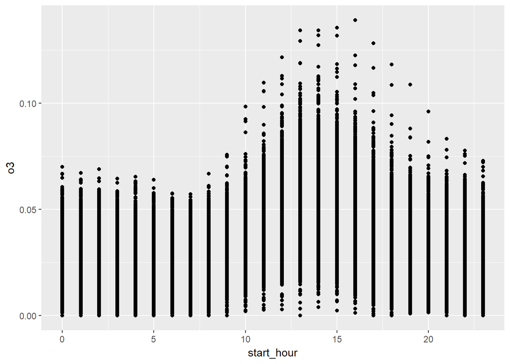

```r
hourly<- o3.filelist %>%
  rbindlist() %>%
  group_by(site = as.factor(site), start_hour, year(date)) %>%
  summarize(o3 = mean(obs, na.rm = TRUE))
#head(hourly)
ggplot(data= hourly)+
  geom_point(mapping=aes(x=start_hour,y=o3))
```

8. How many site names in the CA air quality location dataset “Site Name” contain “San” or “Santa?”.

# this one does not take into account embedded duplicates whereas the second code addresses this via the collapse

```r
san_sum <- sum(str_count(loc$'Site Name',"San"))
```

[output not shown]

```r
santa_sum <- sum(str_count(loc$'Site Name',"Santa"))
```

[output not shown]

```r
total <- sum(santa_sum,san_sum)
```

[output not shown]

```r
total
```

[output not shown]

# or

```r
x <- c("San", "Santa")
name_match <- str_c(x,collapse = "|")
name_subset <- str_subset(loc$`Site Name`,name_match)
```

[output not shown]

```r
count_names <- str_count(name_subset,name_match)
```

[output not shown]

```r
sum(count_names)
```

[output not shown]

9. Identify the number of sites that do not have a complete address (full street address and zip code).

```r
sum(duplicated(loc$Location)) #this is to confirm that Locations are not duplicated
```

[output not shown]

```r
df <- tibble(
  address=loc$Address, Zip=loc$`Zip Code`
)
```

[output not shown]

```r
sum(is.na(df))
```

```
## [1] 0
```

10. How does a semi join differ from an inner join? A semi join is different from an inner join in that the inner join will return one row of x for each matching row of y, whereas the semi join will never duplicate rows of x.

11. Write a function to calculate the annual mean, median, max and min of all sites that have “San” or “Santa” in their name.

# Need to extract all the rows that have data for San and Santa

I was able to get a result for this, but rerunning the code was not functioning. I will have to go back and debug. Here is my attempt.

```r
#library(data.table)
#(tidyverse)

#site.summary <- function(x,y,z){
  #yearly <- x %>%
   # group_by(site = as.factor(site))%>%
    #mutate(year = format(date, "%Y")) %>%
    #group_by(site,year) %>%
    #c <- c(y, z)
  #name_match <- str_c(c,collapse = "|")
  #d <- str_subset(loc$`Site Name`,name_match)
  #San <- subset(yearly, yearly$`Site Name`== d )%>%
   # group_by(site,year )%>%
   # summarize(mean=mean(o3, na.rm=TRUE),median=median(o3, na.rm = TRUE),max=max(o3, na.rm=TRUE),min=min(o3, na.rm=TRUE))
  #return(San)
#}
#site.mean(daily.site,"San","Santa")
```

12. Write a function to caculate the annual daily mean. Apply that function to Merced County. What is the annual daily mean of o3 for Merced County? I was able to get a result for this, but rerunning the code was not functioning. I will have to go back and debug. Here is my attempt.

```r
#library(data.table)
#library(tidyverse)
#site.mean <- function(x){
 # x <- c("Merced")
#  name_match <- str_c(x,collapse = "|")
 # name_subset <- str_subset(loc$`Site Name`,name_match)
#  merceddata <- subset(daily.site, daily.site$`Site Name`== name_subset)
#  mean=mean(x, na.rm=TRUE)
#}
#site.mean(merceddata$o3)
#return(mean)
```